# Lorax Diversity

As you know, there are quite a few species of organism that live in Lorax Land. During your summer internship, you helped conduct biodiversity in 5 sites in Lorax Land. Knowning that you have some experience with R, your supervisor asked you to analyze the data.

Step 1. Set things up

```r
library(formattable)
```

Pull in the data

```r
DF<-read.csv(here("Exam 1", "lorax-community-comparison.csv"), stringsAsFactors = T)
```

The first column identifies the site that was surveyed. The remaining 5 columns each represent one of the species in Lorax Land. Numbers in each cell are the number of individuals of that species detected in the survey.

Let’s set aside the first column into a new dataframe for later use:

```r
DivIndices<-DF %>% select(Site)
```

And make a dataframe that just has the species:

```r
LoraxLand<-DF[,2:6]
```

Now use the `vegan` package to calculate diversity indices.Save the results of each index as a new column in DivIndices

```r
#species richness
DivIndices$SR<-specnumber(LoraxLand)

#simpson's index
DivIndices$Simpson<-diversity(LoraxLand, index = "invsimpson")

#shanon index
DivIndices$Shannon<-diversity(LoraxLand, index = "shannon")
```

Now let’s go from wide to long format for DivIndices

```r
DivLong <- DivIndices %>% pivot_longer(cols = SR:Shannon, values_to = "Value")
```

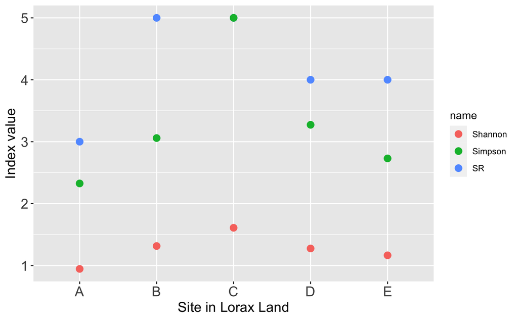

```r
ggplot(DivLong, aes(Site, Value, group = name, color = name))+
  geom_point( size = 3)+
labs(x = "Site in Lorax Land", y = "Index value")+
  theme(axis.text.x = element_text(size =14),
        axis.title.x = element_text(size = 14),
        axis.text.y = element_text(size = 14),
        axis.title.y = element_text(size = 14))
```

Now save the plot

```r
ggsave(here("Exam 1", "LoraxLandDivIndices.png"), width = 6, height =4 )
```

Now calculate the Jaccard index for all pairs of plots

```r
#jaccard index
Jaccard<-betadiver(LoraxLand, "j") #j indicates to use the a/a+b+c formula
#result is of class 'distance' - convert to a matrix
Jaccard<-as.matrix(Jaccard)
```

Now use `betapart`package to get shared species between sites. The function requires a set of presence/absence rather than abundance data so we have to convert our DF dataset to that.

```r
#requires a dataset of presence/absence data so make that first
PresAb<-LoraxLand

PresAb[][PresAb[] != 0]<- 1 #assigns all values > 0  to 1
```

Now we can run the function to get the number of shared species between each pair of plots.

```r
Beta<-betapart.core(PresAb)#result is a list; we just need one part
Shared<-Beta$shared
```

Now it would be ideal if we could create a matrix with number of shared species (“a”) above the diagonal , species richness of each plot along the diagonal, and Jaccard index below the diagonal.

Let’s start by adding row and column names to our existing matrices to keep track of things.

```r
row.names(Jaccard)<-DivIndices$Site
colnames(Jaccard)<-DivIndices$Site

row.names(Shared)<-DivIndices$Site
colnames(Shared)<-DivIndices$Site
```

Since we want the # of shared species above the diagonal, let’s start with the shared matrix. Conveniently, it also has the number of species per plot as its diagonal.

So all we really need to do is put the Jaccard data below the diagonal.

```r
#using base r
Shared[lower.tri(Shared)]<-Jaccard[lower.tri(Jaccard, diag = FALSE)]
#It worked!
```

Now write the matrix to a new location

```r
write.csv(Shared, here("Exam 1", "Lorax_Beta_Diversity.csv"))
```

```r
Alpha<-formattible(DivIndices,
                   align = c("l", "c", "c", "r"))
```

```
Error in formattible(DivIndices, align = c("l", "c", "c", "r")) :
  could not find function "formattible"
```